# Praca domowa nr 3

Paweł Koźmiński

2. października 2019r.

## Oryginalna wersja wykresu

Oryginalna wersja wykresu pochodzi z mediów społecznościowych Ministerstwa Edukajci Narodowej. Wykres rzucił mi się w oczy już w marcu, ze względu na mylący odbiorców słupek dotyczący lat 2017-2020. Posty z ową grafiką zostały już prawdopodobnie podmienione na delikatnie skorygowaną wizualizację znajdującą się pod adresem https://www.facebook.com/ministerstwo.edukacji/photos/a.129261330508041/1727162960717862/?type=3&theater  
Na szczęście w internecie nic nie ginie, a dzięki podzieleniu się wykresem ze znajomym, miałem tę grafikę zapisaną na telefonie.

[figure not shown]

Wykres Ministerstwa Edukacji Narodowej

Spoglądając na wykres opracowany przez pracowników MEN, do głowy odbiorcy natychmiastowo dochodzi wrażenie, że rządowe środki na podwyżki wynagrodzeń nauczycieli rok rocznie rosną wręcz eksponencjalnie. Dopiero gdy adresat się przyjrzy dokładnie w opis osi, może zrozumieć na czym polegała sztuczka autrów. Jeden słupek, opisujący najwyższą wartość, zawiera w sobie tak naprawdę środki z czterech kolejnych lat. Szczerze mówiąc, podobnie mylące wrażenie może sprawić edytowana wersja wykresu. Wierzę, że autorzy wizualizacji nie byli świadomi, że wykresy na pierwszy rzut oka nasuwają czytelnikom inne wnioski niż stan faktyczny.

## Poprawiona wersja wykresu

W mojej wersji wykresu żadne środki Ministerstwa Edukacji Narodowej nie zostały skumulowane - słupki dotyczące każdego z lat, wraz z 2020r., przedstawiają faktyczne dane. Być może ostatni słupek psuje narrację autorów wizualizacji, jednak w celu oddania podkreślenia sumy przeznaczonych środków, dodałem podpis pod wykresem zawierający ową informację. Ponadto, tak naprawdę dzięki zmniejszeniu maksymalnej wysokości słupka, napis “0,0 mld zł” nie jest przecinany przez linię pomocniczą i jest bardziej czytelny.

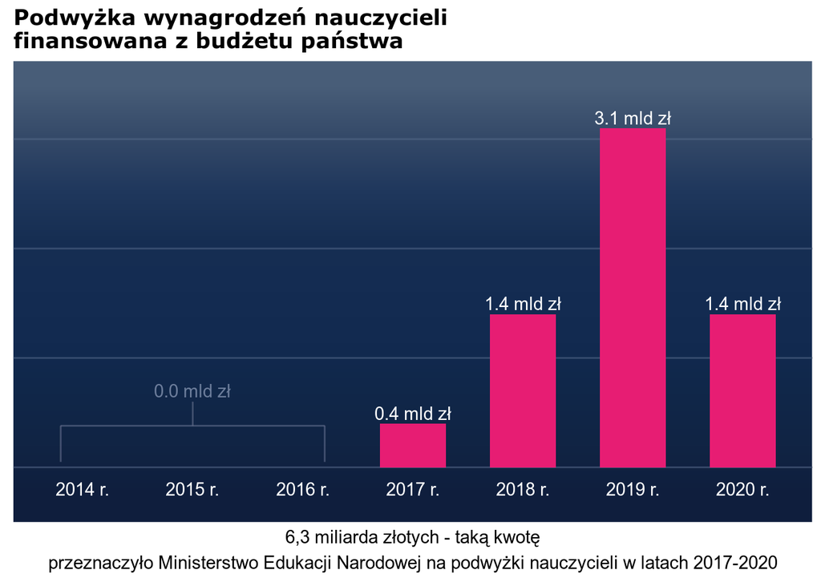

```r
g <- rasterGrob(c("#485D78", "#344968", "#20385D", "#162E52", "#142C52", "#122A50", "#102749", "#112444", "#0F1E3D"),
                width=unit(1,"npc"), height = unit(1,"npc"), interpolate = TRUE) # w celu gradientu w tle


ggplot(df, aes(x = Year, y = Money, label = ifelse(Money>0, paste0(Money, " mld zł"), element_blank()))) + # niezerowe etykiety
  annotation_custom(g, xmin=2013, xmax=Inf, ymin=-0.5, ymax=Inf) + # gradientowe tło
  geom_hline(yintercept = 0:4, color = "#5B6E8E", alpha = 0.5) +
  geom_text(aes(y = Money + 0.097), color = "White") +
  geom_col(fill = "#E71D73", width = 0.6) +
  theme(panel.grid.minor = element_blank(),
        panel.grid.major.x = element_blank(),
        panel.grid.major.y = element_line(color = "#121212"),
        axis.title.x = element_blank(),
        axis.title.y = element_blank(),
        axis.ticks.y = element_blank(),
        axis.text.y = element_blank(),
        axis.ticks.x = element_blank(),
        axis.text.x = element_blank(),
        text = element_text(family = "Verdana", face = "bold"),
        panel.background = element_rect(fill = "white"),) +
  annotate("text", x = 2014, y = -0.2, label = "2014 r.", color = "#FFFFFF") +
  annotate("text", x = 2015, y = -0.2, label = "2015 r.", color = "#FFFFFF") +
  annotate("text", x = 2016, y = -0.2, label = "2016 r.", color = "#FFFFFF") +
  annotate("text", x = 2017, y = -0.2, label = "2017 r.", color = "#FFFFFF") +
  annotate("text", x = 2018, y = -0.2, label = "2018 r.", color = "#FFFFFF") +
  annotate("text", x = 2019, y = -0.2, label = "2019 r.", color = "#FFFFFF") +
  annotate("text", x = 2020, y = -0.2, label = "2020 r.", color = "#FFFFFF") +
  annotate("text", x = 2015, y = 0.7, label = "0.0 mld zł", color = "#6C7D9B") +
  geom_segment(aes(x = 2013.8, y = 0.38, xend = 2016.2, yend = 0.38), colour = "#6C7D9B", alpha = 0.1) +
  geom_segment(aes(x = 2013.8, y = 0.38, xend = 2013.8, yend = 0.05), colour = "#6C7D9B", alpha = 0.1) +
  geom_segment(aes(x = 2016.2, y = 0.38, xend = 2016.2, yend = 0.05), colour = "#6C7D9B", alpha = 0.1) +
  geom_segment(aes(x = 2015, y = 0.6, xend = 2015, yend = 0.38), colour = "#6C7D9B", alpha = 0.1) +
  annotate("text", x = 2017,  y = -0.75,
           label = "6,3 miliarda złotych - taką kwotę\nprzeznaczyło Ministerstwo Edukacji Narodowej na podwyżki nauczycieli w latach 2017-2020") +
  ggtitle("Podwyżka wynagrodzeń nauczycieli\nfinansowana z budżetu państwa") +
  ylim(-0.75, 3.5)
```